## Raymart Ortega Biasbas

##### Senior Business Intelligence Data Scientist

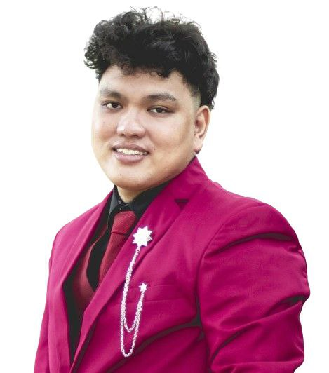

Over 5 years of experience in the gaming industry and more than 4 years of experience in Business Intelligence, with expertise in analyzing data, developing predictive models, and leveraging machine learning algorithms to drive business insights and decision-making. Skilled in data visualization, statistical analysis, and using tools such as R, Python, and SQL to deliver actionable solutions.

### Experience

#### Senior Business Intelligence Data Scientist

**Brand:** M88

**Company:** Phoenixfield Inc

**Dates:** Oct 2023 - Present

- Deployed percentile-based segmentation, pushed it to the database, and made a Tableau visualization.
- Conducted ANOVA with Tukey’s HSD post hoc test for comparative analysis of group differences.
- Created statistical analysis to evaluate the promotion’s impact on player activity.
- Created a Shiny app for forecasting promotion budgets using time series analysis.

#### Business Intelligence Data Scientist

**Brand:** M88

**Company:** Phoenixfield Inc

**Dates:** Dec 2021 - Oct 2023

- Conduct significance tests and deploy a shiny app for the AB testing and compare the performance of the test group vs. the control group and assess the campaign’s effectiveness.
- Created and visualize player segments for a specific product based on the RFM score and determine which of these players are mostly winning and mostly losing.
- Built clusters of members based on their behavior using data mining techniques and evaluate members profitability.
- Built and deploy a model to forecast future revenue for specific product for the stakeholder.
- Built a model to predict potential VIP members based on their behavior.
- Create summary statistics using R markdown and evaluate products or company’s performances.

#### Business Intelligence Officer

**Brand:** M88

**Company:** Phoenixfield Inc

**Dates:** Feb 2020 - Dec 2021

- Analysis and evaluate pre-campaign of promotions, and offer recommendations to optimize or minimize the promotion costs and fraud.
- Analyze and summarize post-campaign of promotions, and give insights of the performance of the promotions.
- Extract and summarize overall financials, and give insights of the company’s overall performance.
- Provide reports of member’s reinvestment value and minimize giving excessive bonus amount.
- Extract and provide data for stakeholders’ adhoc requests.

##### Other Experience

**Sports Trader**

Gorgeous Legend Business Solutions Inc.(Aug 2019 - Jan 2020)

**Analytics Intern**

Pru Life U.K.(Nov 2018-Mar 2019)

### Certificates

**AI & Machine Learning with Python certificate**

**Data Analytics with Python certificate**

### Trainings/Seminar

**Data + AI Summit 2023** (2023)

**Data Analytics with Python** (2022)

**AI & Machine Learning with Python** (2022)

**Learn more, know more. Be EXCELent. Insure your future** (2019)

**Basic SPSS.** (2017)

**Address**: Lower Bicutan Taguig City, Metro Manila, 1632

**Mobile Number**: +63 956-512-2233 (Globe)

**Mobile Number**: +63 960-319-9852 (Smart)

**LinkedIn**: linkedin.com/in/raymartbiasbas

### Skills

**Data Analysis & Modelling** :

Statistical Analysis, Predictive Modeling, Hypothesis Testing, A/B Testing, Regression Analysis

**Tools & Programming languages**:

R, Python, SQL, Microsoft Office

**Databases** :

MS SQL, MYSQL, PostgreSQL, SQLite

**Big Data Technologies**:

Spark, Arrow and Duckdb

**Web Applications**:

Shiny, RMarkdown, HTML, CSS

**Data Visualization**:

Tableau, ggplot2, Plotly,Matplotlib, Seaborn

**Version Control**:

git, GitHub

### Education

**Bachelor of Science in Applied Mathematics major in Actuarial Mathematics**

Polytechnic University of the Philippines - Taguig

2015-2019

**Research:**A regression model for the factors affecting inflation rate in the Philippines